# CLT

# Zadaca 1

Да се направи елементарна статистичка обработка за податоците од дискретното статистичко обележје X – број на точки при фрлање на коцка, ако експериментот се изведува 50 пати и притоа се добиени следните реализации: 1, 3, 1, 6, 2, 6, 4, 6, 3, 3, 4, 3, 1, 4, 4, 1, 4, 5, 3, 5, 4, 1, 1, 1, 5, 4, 3, 2, 1, 4, 6, 4, 3, 2, 2, 2, 3, 6, 1, 2, 2, 3, 5, 3, 1, 3, 6, 2, 4, 1.

## Solution

```r
x <- c(1, 3, 1, 6, 2, 6, 4, 6, 3, 3, 4, 3, 1, 4, 4, 1, 4, 5, 3, 5,
4, 1, 1, 1, 5, 4, 3, 2, 1, 4, 6, 4, 3, 2, 2, 2, 3, 6, 1, 2, 2, 3, 5, 3,
1, 3, 6, 2, 4, 1)
x
```

```
 [1] 1 3 1 6 2 6 4 6 3 3 4 3 1 4 4 1 4 5 3 5 4 1 1 1 5 4 3 2 1 4 6 4 3 2 2 2 3 6 1 2 2 3 5 3 1 3 6 2 4 1
```

```r
df <- as.data.frame(table(x))
df
```

| x | Freq |
| --- | --- |
| 1 | 11 |
| 2 | 8 |
| 3 | 11 |
| 4 | 10 |
| 5 | 4 |
| 6 | 6 |

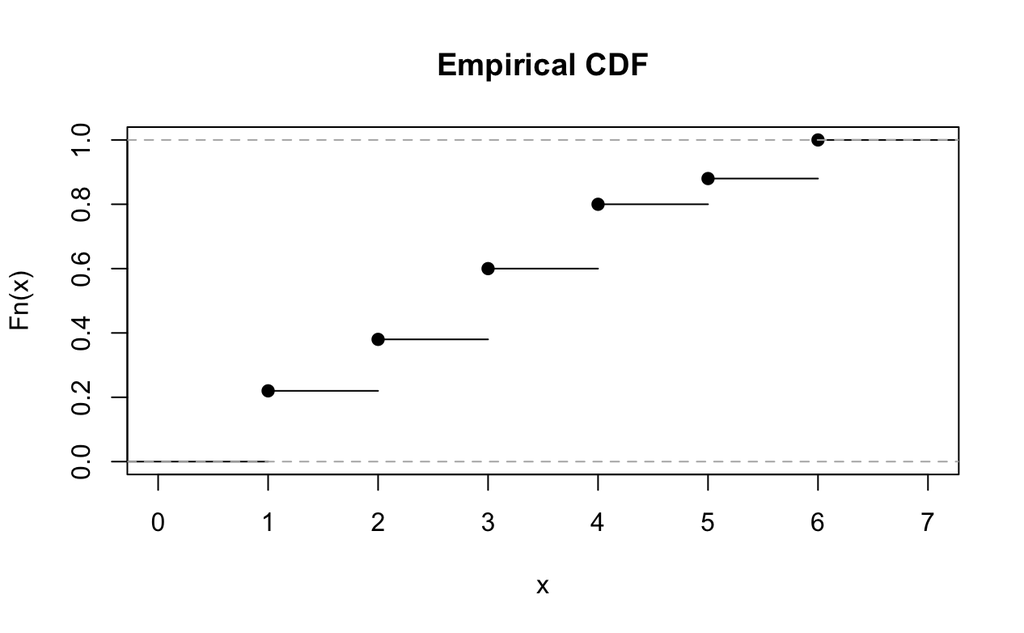

```r
plot(ecdf(x), main = "Empirical CDF")
```

```r
mean(x)
```

```
[1] 3.12
```

```r
var(x)
```

```
[1] 2.679184
```

```r
sd(x)
```

```
[1] 1.636821
```

```r
median(x)
```

```
[1] 3
```

```r
range(x)
```

```
[1] 1 6
```

# Exercise 2

Да се најде медијана, q1=Q0.25 и q3=Q0.75 за следниот примерок: 70, 36, 43, 69, 82, 48, 34, 62, 35, 15, 59, 139, 46, 37, 42, 30, 55, 56, 36, 82, 38, 89, 54, 25, 35, 24, 22, 9, 56, 19

## Solution

```r
y <- c (70, 36, 43, 69, 82, 48, 34, 62, 35, 15, 59, 139, 46, 37, 42, 30, 55, 56, 36, 82, 38, 89, 54, 25, 35, 24, 22, 9, 56, 19)
y
```

```
 [1]  70  36  43  69  82  48  34  62  35  15  59 139  46  37  42  30  55  56  36  82  38  89  54  25  35
[26]  24  22   9  56  19
```

```r
median(y)
```

[output not shown]

1 - quantile = 25% of the given sample needs to be to the left of q1

```r
q1 <- quantile(y, 0.25, names = FALSE, type = 1)
q1
```

```
[1] 34
```

```r
q3 <- quantile(y, 0.75, names = FALSE, type = 1)
q3
```

```
[1] 59
```

```r
IQR <- q3 - q1
IQR
```

```
[1] 25
```

Extreme values are 1.5*IQR left or right of a quantile, namely q1 - 1.5IQR and q3 + 1.5IQR gives the interval that an extreme value should not be in.

```r
ex1 <- q1-1.5*IQR
ex2 <- q3+1.5*IQR
c(ex1, ex2)
```

```
[1] -3.5 96.5
```

```r
outliers <- y[y < ex1 | y > ex2]
outliers
```

```
[1] 139
```

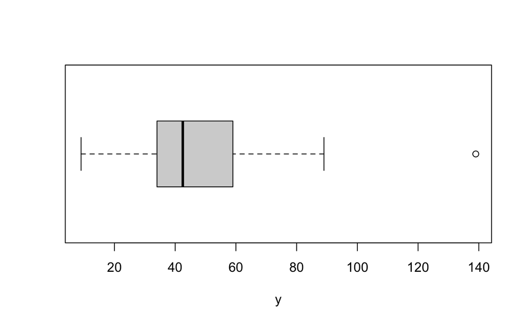

```r
boxplot(y, xlab="y", horizontal = TRUE)
```

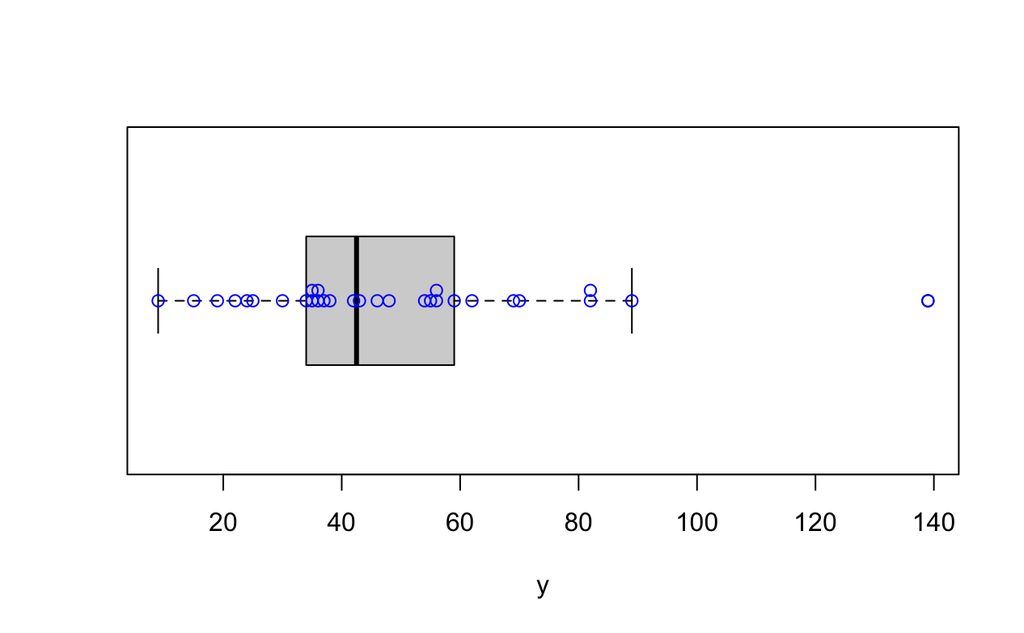

```r
boxplot(y, xlab="y", horizontal = TRUE)
stripchart(y, vertical = FALSE, method = "stack", pch = 1, col = "blue", add = TRUE)
```